# Black-Scholes European option

## Closed-form derivation - pricing - hedging

Monte Carlo simulation and analytical formulas for vanilla options. Hedging strategies included.

European Option Black-Scholes Hedging Monte Carlo

### Overview

- Derive and implement closed-form solutions using the Black-Scholes formula.
- Perform Monte Carlo simulations to price and verify the correctness of Black-Scholes formulas.
- Compare the performance of Monte Carlo pricing with analytical solutions.
- Perform dynamic hedging strategies to manage risk associated with option positions.
- Visualize the results and analyze the effectiveness of hedging strategies.

# Import package

```python
import numpy as np
import pandas as pd
from scipy.stats import norm
import matplotlib.pyplot as plt
from joblib import Parallel, delayed
```

# Black-Scholes formula derivation

Under the Black-Scholes framework, the price of a stock follows a geometric Brownian motion given by the stochastic differential equation: $$ dS_t = \mu S_t dt + S_t \sigma^\top dW_t $$

where:

- $S_t$ is the stock price at time $t$
- $\mu$ is the drift rate of the stock price
- $\sigma$ is the constant volatility vector $d$-dimensional of the stock price
- $W_t$ is a standard Brownian motion vector $d$-dimensional

Under the risk-neutral measure, the drift $\mu$ is replaced by the risk-free rate $r$, leading to the risk-neutral dynamics: $$ dS_t = r S_t dt + S_t \sigma^\top dW_t^Q $$ where $W_t^Q$ is a $d$-dimensional independent Brownian motions under the risk-neutral measure $Q$.

Hence, solving the above SDE as follows: $$ \begin{aligned} d(\ln S_t) &= \frac{1}{S_t} dS_t - \frac{{(dS_t)}^2}{2S_t^2} \\ &=\frac{1}{S_t}(r S_t dt + S_t \sigma^\top dW_t^Q) - \frac{1}{2S_t^2} (S_t^2\sigma^\top\sigma dt)\\ &= \left(r - \frac{1}{2}\sigma^\top\sigma\right) dt + \sigma^\top dW_t^Q\\ \Rightarrow \int_0^T d(\ln S_t) &= \int_0^T \left(r - \frac{1}{2}\sigma^\top\sigma\right) dt + \int_0^T \sigma^\top dW_t^Q\\ \Rightarrow \ln S_T - \ln S_0 &= \left(r - \frac{1}{2}\sigma^\top\sigma\right) T + \sigma^\top W_T^Q\\ \Rightarrow \ln S_T &\overset{Q}{\sim} \mathcal{N}\left(\ln S_0 + \left(r - \frac{1}{2}\sigma^\top\sigma\right) T, \sigma^\top\sigma T\right)\\ \end{aligned} $$

The price of a European call option $C$ with strike price $K$ and maturity $T$ is given by the discounted expected payoff under the risk-neutral measure:

$$ \begin{aligned} C &= e^{-rT} \mathbb{E}^Q[(S_T - K)^+]\\ &= e^{-rT} \mathbb{E}^Q[(S_T - K)\mathbb{1}_{\{S_T > K\}}]\\ &= e^{-rT} \mathbb{E}^Q\left[S_T \mathbb{1}_{\{S_T > K\}}\right] - e^{-rT} K \mathbb{E}^Q\left[\mathbb{1}_{\{S_T > K\}}\right]\\ \end{aligned} $$ where $(x)^+ = \max(x, 0)$.

There are many ways to solve this expectation. The two most common methods are:

- Perform the integration directly using the log-normal distribution of $S_T$.
- Use the change of measure technique (Girsanov's theorem) to simplify the expectation.

**1. Direct integration method:**

With this method, we can compute the two expectations separately. The second expectation is easier to compute: $$ \begin{aligned} \mathbb{E}^Q\left[\mathbb{1}_{\{S_T > K\}}\right] &= \mathbb{P}^Q(S_T > K)\\ &= \mathbb{P}^Q\left(\ln S_T > \ln K\right)\\ &= \Phi\left(\frac{\ln S_0 + \left(r - \frac{1}{2}\sigma^\top\sigma\right) T - \ln K}{\sqrt{\sigma^\top\sigma T}}\right)\\ &= \Phi(d_2)\\ \end{aligned} $$ where $\Phi(\cdot)$ is the cumulative distribution function (CDF) of the standard normal distribution and $d_2 = \frac{\ln\frac{S_0}{K} + \left(r - \frac{1}{2}\sigma^\top\sigma\right) T}{\sqrt{\sigma^\top\sigma T}}$.

In order to solve the first expectation, we need to have a lemma that helps to compute the truncated expectation of a log-normal distribution faster, which is known as the Gaussian Shift Lemma:

**Lemma (Gaussian Shift Lemma)**: Given $x$ as follow: $$ \begin{align} x &\sim \mathcal{N}(\mu, \sigma^2)\\ \phi(x) &= \frac{1}{\sqrt{2\pi \sigma^2}}e^{-\frac{(x-\mu)^2}{2\sigma^2}} \end{align} $$ where $\phi(x)$ is the probability density function (PDF) of $x$. Then, for any constant $a,b,c \in \mathbb{R}$, we have: $$ \begin{aligned} \mathbb{E}[e^{ax+b} \mathbb{1}_{\{x > c\}}] &= \int_{-\infty}^\infty e^{ax+b} \mathbb{1}_{\{x > c\}} \phi(x) dx\\ &= \int_{c}^\infty e^{ax+b} \phi(x) dx\\ &= e^b\int_{c}^\infty e^{ax} \frac{1}{\sqrt{2\pi \sigma^2}}e^{-\frac{(x-\mu)^2}{2\sigma^2}} dx\\ &= e^b\int_{c}^\infty \frac{1}{\sqrt{2\pi \sigma^2}}e^{-\frac{(x-\mu)^2-2\sigma^2ax}{2\sigma^2}} dx\\ &= e^b\int_{c}^\infty \frac{1}{\sqrt{2\pi \sigma^2}}e^{-\frac{(x-(\mu+\sigma^2a))^2 - (\mu+\sigma^2a)^2 + \mu^2}{2\sigma^2}} dx\\ &= e^{\mu a + \frac{1}{2}\sigma^2 a^2 + b} \int_{c}^\infty \frac{1}{\sqrt{2\pi \sigma^2}}e^{-\frac{(x-(\mu+\sigma^2a))^2}{2\sigma^2}} dx\\ &= e^{\mu a + \frac{1}{2}\sigma^2 a^2 + b} \left(1 - \Phi\left(\frac{c - (\mu + \sigma^2 a)}{\sigma}\right)\right)\\ &= e^{\mu a + \frac{1}{2}\sigma^2 a^2 + b} \Phi\left(\frac{\mu + \sigma^2 a - c}{\sigma}\right)\\ \end{aligned} $$

Applying the lemma with $x = \ln S_T$, $a = 1$, $b = 0$, $c = \ln K$, $\mu = \ln S_0 + \left(r - \frac{1}{2}\sigma^\top\sigma\right) T$, and $\sigma^2 = \sigma^\top\sigma T$, we have: $$ \begin{aligned} \mathbb{E}^Q\left[S_T \mathbb{1}_{\{S_T > K\}}\right] &= \mathbb{E}^Q\left[e^{\ln S_T} \mathbb{1}_{\{\ln S_T > \ln K\}}\right]\\ &= e^{\mu + \frac{1}{2}\sigma^2} \Phi\left(\frac{\mu + \sigma^2 - c}{\sigma}\right)\\ &= e^{\ln S_0 + \left(r - \frac{1}{2}\sigma^\top\sigma\right) T + \frac{1}{2}\sigma^\top\sigma T} \Phi\left(\frac{\ln S_0 + \left(r - \frac{1}{2}\sigma^\top\sigma\right) T + \sigma^\top\sigma T - \ln K}{\sqrt{\sigma^\top\sigma T}}\right)\\ &= S_0 e^{rT} \Phi(d_1)\\ \end{aligned} $$ where $d_1 = \frac{\ln\frac{S_0}{K} + \left(r + \frac{1}{2}\sigma^\top\sigma\right) T}{\sqrt{\sigma^\top\sigma T}}$.

Combining the two expectations, we have the Black-Scholes formula for European call option price: $$ \begin{aligned} C &= e^{-rT} \mathbb{E}^Q\left[S_T \mathbb{1}_{\{S_T > K\}}\right] - e^{-rT} K \mathbb{E}^Q\left[\mathbb{1}_{\{S_T > K\}}\right]\\ &= e^{-rT} \left(S_0 e^{rT} \Phi(d_1)\right) - e^{-rT} K \Phi(d_2)\\ &= S_0 \Phi(d_1) - K e^{-rT} \Phi(d_2)\\ \end{aligned} $$

**2. Change of measure method:**

Under the risk-neutral measure, we have: $$ \begin{aligned} \frac{S_T}{e^{rT}} \frac{1}{S_0}&= \exp\left(-\frac{1}{2}\sigma^\top\sigma T + \sigma^\top W_T^Q\right)\\ \end{aligned} $$ is a valid exponential martingale. Hence, we can use the above ratio to define a new probability measure $\tilde{Q}$ with the Radon-Nikodym derivative as follows: $$ \frac{d\tilde{Q}}{dQ} = \frac{S_T}{e^{rT}} \frac{1}{S_0} $$ The Girsanov's theorem states that under the new measure $\tilde{Q}$, the process: $$ \tilde{W}_t = W_t^Q - \sigma t $$ is a standard Brownian motion. Therefore, we can rewrite the stock price dynamics under the new measure $\tilde{Q}$ as follows: $$ \begin{aligned} dS_t &= r S_t dt + S_t \sigma^\top dW_t^Q \\ &= r S_t dt + S_t \sigma^\top (d\tilde{W}_t + \sigma dt)\\ &= (r + \sigma^\top\sigma) S_t dt + S_t \sigma^\top d\tilde{W}_t\\ \end{aligned} $$ Solving the above SDE, we have: $$ \begin{aligned} \ln S_T &\overset{\tilde{Q}}{\sim} \mathcal{N}\left(\ln S_0 + \left(r + \frac{1}{2}\sigma^\top\sigma\right) T, \sigma^\top\sigma T\right)\\ \end{aligned} $$ Using the change of measure, we can rewrite the first expectation as follows: $$ \begin{aligned} \mathbb{E}^Q\left[S_T \mathbb{1}_{\{S_T > K\}}\right] &= \mathbb{E}^{\tilde{Q}}\left[\frac{dQ}{d\tilde{Q}} S_T \mathbb{1}_{\{S_T > K\}}\right]\\ &= \mathbb{E}^{\tilde{Q}}\left[\frac{e^{rT} S_0}{S_T} S_T \mathbb{1}_{\{S_T > K\}}\right]\\ &= e^{rT} S_0 \mathbb{E}^{\tilde{Q}}\left[\mathbb{1}_{\{S_T > K\}}\right]\\ &= e^{rT} S_0 \mathbb{P}^{\tilde{Q}}(S_T > K)\\ &= e^{rT} S_0 \mathbb{P}^{\tilde{Q}}(\ln S_T > \ln K)\\ &= e^{rT} S_0 \Phi\left(\frac{\ln S_0 + \left(r + \frac{1}{2}\sigma^\top\sigma\right) T - \ln K}{\sqrt{\sigma^\top\sigma T}}\right)\\ &= e^{rT} S_0 \Phi(d_1)\\ \end{aligned} $$ Combining the two expectations, we have the Black-Scholes formula for European call option price: $$ \begin{aligned} C &= e^{-rT} \mathbb{E}^Q\left[S_T \mathbb{1}_{\{S_T > K\}}\right] - e^{-rT} K \mathbb{E}^Q\left[\mathbb{1}_{\{S_T > K\}}\right]\\ &= e^{-rT} \left(e^{rT} S_0 \Phi(d_1)\right) - e^{-rT} K \Phi(d_2)\\ &= S_0 \Phi(d_1) - K e^{-rT} \Phi(d_2)\\ \end{aligned} $$

For the more complex structured option, the change of measure technique is often more convenient to use than the direct integration method. This is because the change of measure can simplify the expectations significantly by transforming them into probabilities under the new measure, which are often easier to compute. This will be illustrated in the a different project.

# Black-Scholes formula implementation

```python
def BlackScholes(S, K, sgm, r, T, callput):
    d1 = (np.log(S / K) + (r + 0.5 * sgm**2) * T) / (sgm * np.sqrt(T))
    d2 = d1 - sgm * np.sqrt(T)

    if callput not in [1, -1]:
        raise ValueError("callput must be 1 for call or -1 for put")
    return callput * (
        S * norm.cdf(callput * d1) - K * np.exp(-r * T) * norm.cdf(callput * d2)
    )
```

# Monte Carlo pricing of a Black/Scholes call option

Another way to price a European option is to use Monte Carlo simulation. Instead of solving the expectation analytically, we can approximate it using random sampling. In the Black/Scholes model, the price of the underlying stock follows Geometric Brownian motion, with the dynamics under the risk-neutral measure given by $$S(T)=S(0)\exp\left\{\left(r−\frac12\sigma^\top\sigma\right)T+\sigma^\top W^Q(T)\right\}$$ where $W^Q(T)$ is a standard Brownian motion vector $d$-dimensional under the risk-neutral measure which has the distribution $W^Q(T) \sim \mathcal{N}(0, T I_d)$.

Recall that the time 0 price of a European call option (and analogously the put option) expiring at time $T$ with strike price $K$ can be expressed as the expectation under the risk-neutral measure of $$C=E\left[e^{−rT}\max(0,S(T)−K)\right]$$ Thus we can write a Python function which simulates the terminal stock prices using Monte Carlo sampling and computes the option price as the discounted average of the payoffs. The function also calculates the standard deviation of the simulation mean to provide an estimate of the pricing error.

**Error estimation for Monte Carlo methods**

Monte Carlo simulation without error bounds is meaningless. By the Central Limit Theorem, we know that for a large number $N$ of simulations, the simulation mean $\mu$ is approximately normally distributed, with standard deviation $\sqrt{\frac{\sigma^2}N}$ where the simulation variance is an estimate for $\sigma^2$.

Thus, if there is no bias, the simulation mean is normally distributed around the target value with a standard deviation, which decreases with $\sqrt{N}$. A 95% confidence interval for the target value is therefore approximately given by

```python
def BlackScholesMC(S, K, sgm, r, T, callput, n):
    np.random.seed(0)
    w = np.random.standard_normal(n)
    ST = S * np.exp((r - 0.5 * sgm**2) * T + sgm * np.sqrt(T) * w)
    payoff = callput * (ST - K)
    payoff = payoff * (payoff > 0)
    MC = np.exp(-r * T) * np.mean(payoff)
    MCstd = np.exp(-r * T) * np.std(payoff) / np.sqrt(n)
    return MC, MCstd
```

# Analytical vs Monte Carlo pricing comparison

To compare the analytical Black-Scholes pricing with the Monte Carlo simulation, we can choose a set of parameters for the option and underlying asset, compute the option price using both methods, and then analyze the results. We choose the following parameters for the comparison:

- Current stock price $S_0 = 100$
- Strike price $K = 100$
- Volatility $\sigma = 0.2$
- Risk-free interest rate $r = 0.05$
- Time to maturity $T = 1$ year
- Number of Monte Carlo simulations $n = 100000$

During the comparison, we will also vary the parameters such as volatility, time to maturity, and number of simulations to see how they affect the accuracy and convergence of the Monte Carlo method compared to the analytical solution. We will visualize the results using plots to illustrate the differences and convergence behavior.

```python
print("Analytical Black-Scholes Call Price:", BlackScholes(100, 100, 0.2, 0.05, 1, 1))
mc_price, mc_std = BlackScholesMC(100, 100, 0.2, 0.05, 1, 1, 100000)
print("Monte Carlo Black-Scholes Call Price:", mc_price, "±", norm.ppf(0.975) * mc_std)
```

```
Analytical Black-Scholes Call Price: 10.450583572185565
Monte Carlo Black-Scholes Call Price: 10.43239318729288 ± 0.09098403282178397
```

## Number of simulations effect

If we increase the number of Monte Carlo simulations, we should observe that the Monte Carlo price converges to the analytical Black-Scholes price, and the confidence interval narrows, indicating increased accuracy.

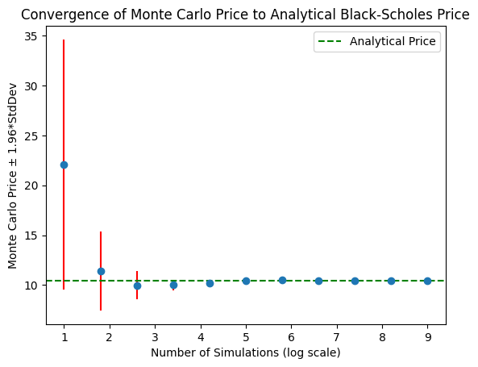

```python
power = np.linspace(1, 9, 11)


def run_simulation(n):
    n = int(10**n)
    mc_price, mc_std = BlackScholesMC(100, 100, 0.2, 0.05, 1, 1, n)
    return mc_price, mc_std


results = Parallel(n_jobs=-1)(delayed(run_simulation)(i) for i in power)
mc_prices, mc_stds = zip(*results)

plt.errorbar(
    power,
    mc_prices,
    yerr=[norm.ppf(0.975) * sd for sd in mc_stds],
    fmt="o",
    ecolor="r",
    capthick=2,
)
plt.xlabel("Number of Simulations (log scale)")
plt.ylabel("Monte Carlo Price ± 1.96*StdDev")
plt.title("Convergence of Monte Carlo Price to Analytical Black-Scholes Price")
plt.axhline(
    y=BlackScholes(100, 100, 0.2, 0.05, 1, 1),
    color="g",
    linestyle="--",
    label="Analytical Price",
)
plt.legend()
plt.show()
```

From the plot, it can be seen that the higher the number of simulations, the closer the Monte Carlo price is to the analytical Black-Scholes price, and the narrower the confidence interval becomes. This demonstrates the convergence of the Monte Carlo method to the true option price as the number of simulations increases.

## Volatility effect

Increasing the volatility should increase the option price, as higher volatility increases the potential upside of the option. We should observe that both the analytical and Monte Carlo prices increase with volatility, and the Monte Carlo price should converge to the analytical price as the number of simulations increases.

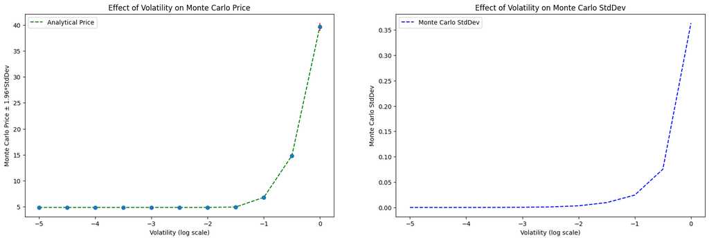

```python
vola = np.linspace(-5, 0, 11)


def run_simulation(vol):
    vol = 10**vol
    mc_price, mc_std = BlackScholesMC(100, 100, vol, 0.05, 1, 1, 100000)
    ana_price = BlackScholes(100, 100, vol, 0.05, 1, 1)
    return mc_price, mc_std, ana_price


results = Parallel(n_jobs=-1)(delayed(run_simulation)(i) for i in vola)
mc_prices, mc_stds, ana_prices = zip(*results)

fig, (ax1, ax2) = plt.subplots(1, 2, figsize=(20, 6))

ax1.errorbar(
    vola,
    mc_prices,
    yerr=[norm.ppf(0.975) * sd for sd in mc_stds],
    fmt="o",
    ecolor="r",
    capthick=2,
)
ax1.set_xlabel("Volatility (log scale)")
ax1.set_ylabel("Monte Carlo Price ± 1.96*StdDev")
ax1.set_title("Effect of Volatility on Monte Carlo Price")
ax1.plot(vola, ana_prices, label="Analytical Price", color="g", linestyle="--")
ax1.legend()

ax2.plot(vola, mc_stds, label="Monte Carlo StdDev", color="b", linestyle="--")
ax2.set_xlabel("Volatility (log scale)")
ax2.set_ylabel("Monte Carlo StdDev")
ax2.set_title("Effect of Volatility on Monte Carlo StdDev")
ax2.legend()
plt.show()
```

From the plot, we can see that as volatility increases, both the Monte Carlo price and the analytical Black-Scholes price increase. The Monte Carlo price follows the analytical price, yet, the higher the volatility, the larger the standard deviation of the Monte Carlo price, indicating increased uncertainty in the pricing due to higher volatility.

## Time to maturity effect

Increasing the time to maturity should also increase the option price, as it provides more time for the underlying asset to move favorably. We should observe that both the analytical and Monte Carlo prices increase with time to maturity, and the Monte Carlo price should converge to the analytical price as the number of simulations increases.

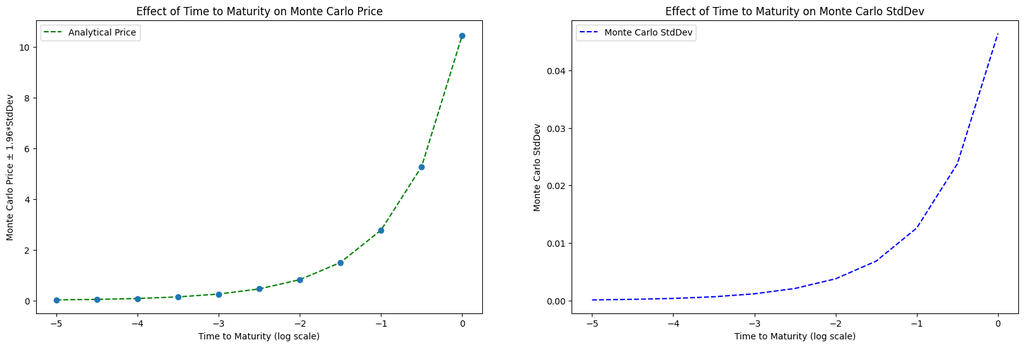

```python
tmt = np.linspace(-5, 0, 11)


def run_simulation(t):
    t = 10**t
    mc_price, mc_std = BlackScholesMC(100, 100, 0.2, 0.05, t, 1, 100000)
    ana_price = BlackScholes(100, 100, 0.2, 0.05, t, 1)
    return mc_price, mc_std, ana_price


results = Parallel(n_jobs=-1)(delayed(run_simulation)(i) for i in tmt)
mc_prices, mc_stds, ana_prices = zip(*results)

fig, (ax1, ax2) = plt.subplots(1, 2, figsize=(20, 6))

ax1.errorbar(
    tmt,
    mc_prices,
    yerr=[norm.ppf(0.975) * sd for sd in mc_stds],
    fmt="o",
    ecolor="r",
    capthick=2,
)
ax1.set_xlabel("Time to Maturity (log scale)")
ax1.set_ylabel("Monte Carlo Price ± 1.96*StdDev")
ax1.set_title("Effect of Time to Maturity on Monte Carlo Price")
ax1.plot(tmt, ana_prices, label="Analytical Price", color="g", linestyle="--")
ax1.legend()

ax2.plot(tmt, mc_stds, label="Monte Carlo StdDev", color="b", linestyle="--")
ax2.set_xlabel("Time to Maturity (log scale)")
ax2.set_ylabel("Monte Carlo StdDev")
ax2.set_title("Effect of Time to Maturity on Monte Carlo StdDev")
ax2.legend()
plt.show()
```

From the plot, we can see that the longer the time to maturity, the higher both the Monte Carlo price and the analytical Black-Scholes price. The Monte Carlo price follows the analytical price, yet, the longer the maturity, the larger the standard deviation of the Monte Carlo price, indicating increased uncertainty in the pricing due to the extended time horizon.

In conclusion, the Monte Carlo simulation method effectively approximates the Black-Scholes option pricing, with accuracy improving as the number of simulations increases. Both volatility and time to maturity significantly impact option prices, with higher values leading to increased prices and uncertainty in the Monte Carlo estimates. Furthermore, the Monte Carlo method requires an extensive resource to achieve high accuracy, especially for options with high volatility or long maturities.

# Dynamic hedging of a Black/Scholes call option

For option sellers, managing the risk associated with option positions is crucial. One common approach to mitigate this risk is through dynamic hedging, which involves continuously adjusting the hedge position in the underlying asset to offset changes in the option's value. In this section, we will implement a dynamic hedging strategy for a European call option using the Black-Scholes model.

In order to perform dynamic hedging, we need to investigate the option's sensitivity to changes in the underlying asset price. We apply Ito's lemma to the Black-Scholes formula for a European call option: $$ \begin{aligned} dC &= \frac{\partial C}{\partial t} dt + \frac{\partial C}{\partial S} dS + \frac{1}{2} \frac{\partial^2 C}{\partial S^2} (dS)^2 \\ \end{aligned} $$

The simplest dynamic hedging strategy is delta hedging, which involves holding a position in the underlying asset equal to the option's delta ($\Delta$), which is the first derivative of the option price with respect to the underlying asset price: $$ \Delta = \frac{\partial C}{\partial S} = \Phi(d_1) $$ Thus, at each time step, we adjust our position in the underlying asset to match the option's delta. This way, small changes in the underlying asset price will be offset by changes in the value of the option position, effectively neutralizing the risk.

For the rest of the hedging strategy, we will invest into or borrow from a risk-free asset (bond) to finance the purchase of the underlying asset. We assume that the risk-free asset is a 1-dollar face value bond that grows at the risk-free rate $r$.

Steps to implement the dynamic hedging strategy:

1. After selling the option, initialize the hedge position by calculating the initial delta and purchasing the corresponding amount of the underlying asset. The rest of the money is invested in the risk-free asset till the maturity.
2. At a new time step, recalculate the option's delta based on the updated underlying asset price and time to maturity.
3. Adjust the hedge position by buying or selling the underlying asset to match the new delta. Update the position in the risk-free asset accordingly.
4. Any profits from rebalancing the hedge are reinvested in the risk-free asset and any losses are financed by borrowing from the risk-free asset.
5. Repeat steps 2-4 until the option reaches maturity.

The profits/losses from daily rebalancing are given by:

$$ \Pi(t_i) = S(t_i) \left( d_1(t_i)-d_1(t_{i-1})\right) - K e^{-r(T-t_i)} \left( \Phi(d_2(t_i)) - \Phi(d_2(t_{i-1}))\right) $$

where $d_1(t_i)$ and $d_2(t_i)$ are calculated at time $t_i$ and $t_{i-1}$ respectively. After rebalancing at each time step, the profits/losses are accumulated to evaluate the overall performance of the hedging strategy at maturity by investing or borrowing from the risk-free asset.

$$ \text{Total Profit/Loss} = \sum_{i=1}^{N} \Pi(t_i) e^{r(T-t_i)} $$

```python
def BlackScholesHedgePayoff(S, K, sgm, r, T, callput, info_return=False):
    time_to_mat = np.tile(np.linspace(T, 0, S.shape[1]), (S.shape[0], 1))
    d1 = (np.log(S[:, :-1] / K) + (r + (sgm**2) / 2) * time_to_mat[:, :-1]) / (
        sgm * np.sqrt(time_to_mat[:, :-1])
    )
    d2 = d1 - (sgm * np.sqrt(time_to_mat[:, :-1]))
    stock_pos = norm.cdf(callput * d1)
    bond_pos = -K * norm.cdf(callput * d2)
    old_new_val = S[:, 1:] * stock_pos + np.exp(-r * time_to_mat[:, 1:]) * bond_pos
    new_val = (
        S[:, 1:-1] * stock_pos[:, 1:]
        + np.exp(-r * time_to_mat[:, 1:-1]) * bond_pos[:, 1:]
    )
    new_val = np.column_stack((new_val, np.maximum(0, callput * (S[:, -1] - K))))
    payoff = old_new_val - new_val
    payoff_at_maturity = payoff * np.exp(r * time_to_mat[:, 1:])
    cum_payoff = np.sum(payoff_at_maturity, axis=1)
    if info_return:
        df = []
        for i in range(S.shape[0]):
            df.append(
                pd.DataFrame(
                    {
                        "Time to maturity": time_to_mat[i, :],
                        "Stock Price": S[i, :],
                        "Delta": np.append(
                            stock_pos[i, :],
                            norm.cdf(callput * np.inf * (1 if S[i, -1] > K else -1)),
                        ),
                        "Bond Position": np.append(
                            bond_pos[i, :],
                            -K
                            * norm.cdf(callput * np.inf * (1 if S[i, -1] > K else -1)),
                        ),
                        "Payoff": np.insert(payoff[i, :], 0, 0),
                        "Cumulative Payoff": np.insert(
                            np.cumsum(payoff_at_maturity[i, :]), 0, 0
                        ),
                    }
                )
            )
        return cum_payoff, df
    return cum_payoff
```

## Monte Carlo simulation of stock price paths and dynamic hedging

To evaluate the effectiveness of the dynamic hedging strategy, we can simulate multiple stock price paths using Monte Carlo methods and apply the hedging strategy to each path. The simulation can be performed as follows: $$S(t_i)=S(t_{i-1})\exp\left\{\left(r−\frac12\sigma^\top\sigma\right)(t_i - t_{i-1})+\sigma^\top (W^Q(t_i)-W^Q(t_{i-1}))\right\}$$ where $W^Q(t_i)-W^Q(t_{i-1}) \sim \mathcal{N}(0, (t_i - t_{i-1}) I_d)$, t_i are the discrete time steps.

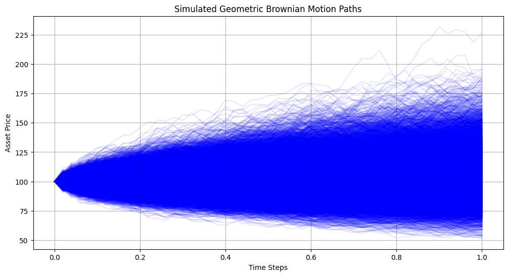

```python
def simulate_gbm_paths(S0, r, sgm, T, steps, n):
    np.random.seed(0)
    dt = T / steps
    S = np.zeros((n, steps + 1))
    S[:, 0] = S0
    for t in range(1, steps + 1):
        z = np.random.standard_normal(n)
        S[:, t] = S[:, t - 1] * np.exp((r - 0.5 * sgm**2) * dt + sgm * np.sqrt(dt) * z)
    return S


S_paths = simulate_gbm_paths(100, 0.05, 0.2, 1, 50, 10000)
plt.figure(figsize=(12, 6))
for i in range(len(S_paths)):
    plt.plot(np.linspace(0, 1, 51), S_paths[i], color="blue", alpha=0.1)
plt.title("Simulated Geometric Brownian Motion Paths")
plt.xlabel("Time Steps")
plt.ylabel("Asset Price")
plt.grid()
plt.show()

payoffs, df_list = BlackScholesHedgePayoff(S_paths, 100, 0.2, 0.05, 1, 1, True)
```

```python
display(df_list[0])
```

|  | Time to maturity | Stock Price | Delta | Bond Position | Payoff | Cumulative Payoff |
| --- | --- | --- | --- | --- | --- | --- |
| 0 | 1.00 | 100.000000 | 0.636831 | -55.961769 | 0.000000 | 0.000000 |
| 1 | 0.98 | 105.179154 | 0.726253 | -65.672095 | -0.159403 | -0.167409 |
| 2 | 0.96 | 104.642354 | 0.717185 | -64.748491 | 0.068640 | -0.095394 |
| 3 | 0.94 | 105.687169 | 0.733881 | -66.665202 | 0.064090 | -0.028220 |
| 4 | 0.92 | 106.866835 | 0.752353 | -68.796079 | 0.061107 | 0.035764 |
| 5 | 0.90 | 101.223017 | 0.653987 | -58.174911 | -0.196936 | -0.170237 |
| 6 | 0.88 | 101.473136 | 0.657730 | -58.654183 | 0.078851 | -0.087838 |
| 7 | 0.86 | 98.485890 | 0.595733 | -52.266551 | -0.012963 | -0.101371 |
| 8 | 0.84 | 93.490806 | 0.481492 | -40.915739 | -0.203469 | -0.313568 |
| 9 | 0.82 | 95.071550 | 0.515107 | -44.305347 | 0.057628 | -0.253528 |
| 10 | 0.80 | 95.448049 | 0.520980 | -44.975863 | 0.083585 | -0.166532 |
| 11 | 0.78 | 94.207354 | 0.488546 | -41.864957 | 0.063615 | -0.100387 |
| 12 | 0.76 | 96.987413 | 0.551591 | -48.218404 | 0.001958 | -0.098353 |
| 13 | 0.74 | 102.277888 | 0.667128 | -60.254843 | -0.217571 | -0.324125 |
| 14 | 0.72 | 99.049345 | 0.595106 | -52.829848 | -0.028731 | -0.353910 |
| 15 | 0.70 | 100.297348 | 0.621938 | -55.695069 | 0.075477 | -0.275745 |
| 16 | 0.68 | 101.995468 | 0.658517 | -59.618895 | 0.061766 | -0.211843 |
| 17 | 0.66 | 98.688202 | 0.580460 | -51.618893 | -0.037052 | -0.250138 |
| 18 | 0.64 | 100.479912 | 0.621690 | -55.958723 | 0.060396 | -0.187779 |
| 19 | 0.62 | 102.283382 | 0.662375 | -60.313667 | 0.060594 | -0.125277 |
| 20 | 0.60 | 102.207342 | 0.659846 | -60.145809 | 0.095640 | -0.026724 |
| 21 | 0.58 | 102.383035 | 0.663185 | -60.597952 | 0.097359 | 0.073499 |
| 22 | 0.56 | 100.909469 | 0.626428 | -56.857268 | 0.071705 | 0.147241 |
| 23 | 0.54 | 104.856437 | 0.718996 | -66.745360 | -0.081670 | 0.063335 |
| 24 | 0.52 | 106.315195 | 0.750796 | -70.290564 | 0.073370 | 0.138638 |
| 25 | 0.50 | 108.550834 | 0.796068 | -75.371778 | 0.041524 | 0.181213 |
| 26 | 0.48 | 105.375125 | 0.732482 | -68.501638 | -0.006878 | 0.174168 |
| 27 | 0.46 | 109.480898 | 0.817306 | -77.920138 | -0.082238 | 0.090017 |
| 28 | 0.44 | 107.996452 | 0.791613 | -75.154726 | 0.069464 | 0.161026 |
| 29 | 0.42 | 109.393532 | 0.821084 | -78.520430 | 0.071805 | 0.234355 |
| 30 | 0.40 | 111.478544 | 0.860020 | -82.993705 | 0.044262 | 0.279511 |
| 31 | 0.38 | 116.728327 | 0.929269 | -91.102262 | -0.127396 | 0.149672 |
| 32 | 0.36 | 111.720677 | 0.871518 | -84.461240 | -0.070603 | 0.077786 |
| 33 | 0.34 | 108.092907 | 0.808230 | -77.480747 | -0.021829 | 0.055583 |
| 34 | 0.32 | 105.125296 | 0.738842 | -70.077891 | 0.009091 | 0.064821 |
| 35 | 0.30 | 103.899380 | 0.705712 | -66.689543 | 0.104263 | 0.170660 |
| 36 | 0.28 | 100.812040 | 0.603194 | -56.190200 | -0.018322 | 0.152079 |
| 37 | 0.26 | 94.857771 | 0.367230 | -32.954186 | -0.552897 | -0.408052 |
| 38 | 0.24 | 95.038887 | 0.363969 | -32.785338 | 0.143075 | -0.263250 |
| 39 | 0.22 | 93.964072 | 0.308712 | -27.648587 | 0.111653 | -0.150362 |
| 40 | 0.20 | 96.591159 | 0.408563 | -37.422441 | 0.031862 | -0.118180 |
| 41 | 0.18 | 93.816390 | 0.273002 | -24.553393 | -0.035897 | -0.154402 |
| 42 | 0.16 | 96.240409 | 0.367301 | -33.760413 | 0.058310 | -0.095624 |
| 43 | 0.14 | 99.355831 | 0.517786 | -48.794012 | -0.022899 | -0.118684 |
| 44 | 0.12 | 94.226425 | 0.230523 | -21.000406 | -0.559544 | -0.681595 |
| 45 | 0.10 | 92.995506 | 0.149745 | -13.549766 | 0.098525 | -0.582576 |
| 46 | 0.08 | 93.537250 | 0.139613 | -12.742953 | 0.144084 | -0.437914 |
| 47 | 0.06 | 95.794325 | 0.214378 | -20.036659 | 0.109852 | -0.327732 |
| 48 | 0.04 | 93.009838 | 0.040787 | -3.740538 | -0.117927 | -0.445895 |
| 49 | 0.02 | 98.041210 | 0.257875 | -24.882367 | -0.162808 | -0.608866 |
| 50 | 0.00 | 100.236745 | 1.000000 | -100.000000 | 0.729396 | 0.120530 |

## Visualising the profit/loss distribution

Adapt the Monte Carlo code that we have written, we now can plot the histogram of the P/L to see the distribution of the P/L of the hedging strategy under various scenarios.

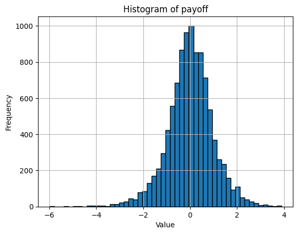

```python
plt.hist(payoffs, bins=50, edgecolor="black")
plt.title("Histogram of payoff")
plt.xlabel("Value")
plt.ylabel("Frequency")
plt.grid(True)
plt.show()
```

It can be seen that the profit/loss distribution of the dynamically hedged position is centered around zero, indicating that the hedging strategy effectively neutralizes the risk associated with the option position. The spread of the distribution reflects the residual risk due to discrete rebalancing and market fluctuations. Overall, dynamic hedging proves to be a valuable technique for managing option risk in a Black-Scholes framework. In order to investigate further, one could analyze the impact of different rebalancing frequencies, insufficient estimated drift and volatility parameters on the effectiveness of the hedging strategy.

The following are the observations from changing the parameters of the hedging strategy. The simulation parameters are set as follows unless otherwise stated:

- Current stock price S0 = 100
- Strike price K = 100
- Volatility σ = 0.2
- Risk-free interest rate r = 0.05
- Time to maturity T = 1 year
- Number of simulations N = 1000

## Effect of rebalancing frequency on hedging

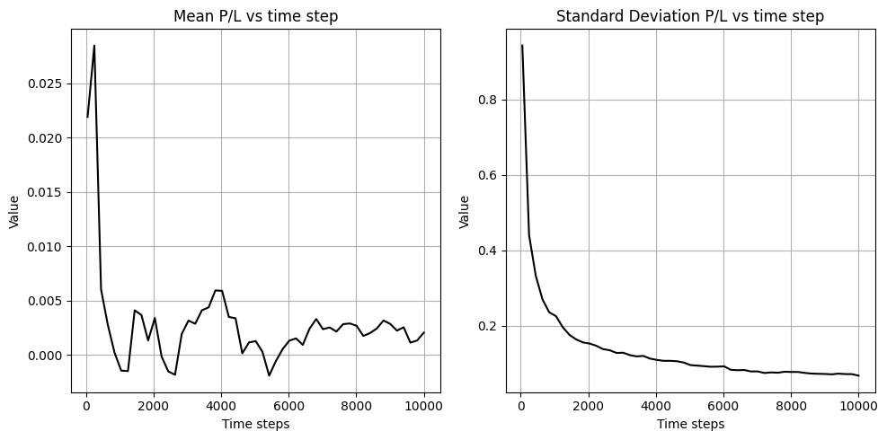

```python
steps = np.linspace(50, 10000, 51)


def process_step(x):
    S = simulate_gbm_paths(100, 0.05, 0.2, 1, int(x), 1000)
    payoffs = BlackScholesHedgePayoff(S, 100, 0.2, 0.05, 1, 1)
    MC = np.mean(payoffs)
    MCstd = np.std(payoffs)
    return MC, MCstd


results = Parallel(n_jobs=-1)(delayed(process_step)(i) for i in steps)
mean, std = zip(*results)
fig, axs = plt.subplots(1, 2, figsize=(10, 5))
axs[0].plot(
    steps,
    mean,
    linestyle="-",
    color="black",
)
axs[0].set_title("Mean P/L vs time step")
axs[0].set_xlabel("Time steps")
axs[0].set_ylabel("Value")
axs[0].grid(True)
axs[1].plot(
    steps,
    std,
    linestyle="-",
    color="black",
)
axs[1].set_title("Standard Deviation P/L vs time step")
axs[1].set_xlabel("Time steps")
axs[1].set_ylabel("Value")
axs[1].grid(True)
plt.tight_layout()
plt.show()
```

- When increasing the number of time step, the standard deviation of the P/L tend to reduce and the mean tends to reach closer to 0 with less fluctuation. The opposite happens when decreasing the number of time step.
- The means to reach closer to 0 with less fluctuation when increasing the number of time step, and the opposite happens when decreasing the number of time step.

This can be explained as when increasing in the number of time steps, we can increase in the frequency of hedging. Since then, the payoff will tends to be less fluctuated as we can reach to continously hedging if we keeps on increasing the time steps, which helps us to secure better the final payoff at the maturity. Furthermore, as we are reaching to the continously hedging when increase in the number of time step and the term structure is fixed, the mean of the P/L tends to reach to 0 with less fluctuation.

## Effect of insufficient estimated drift on hedging

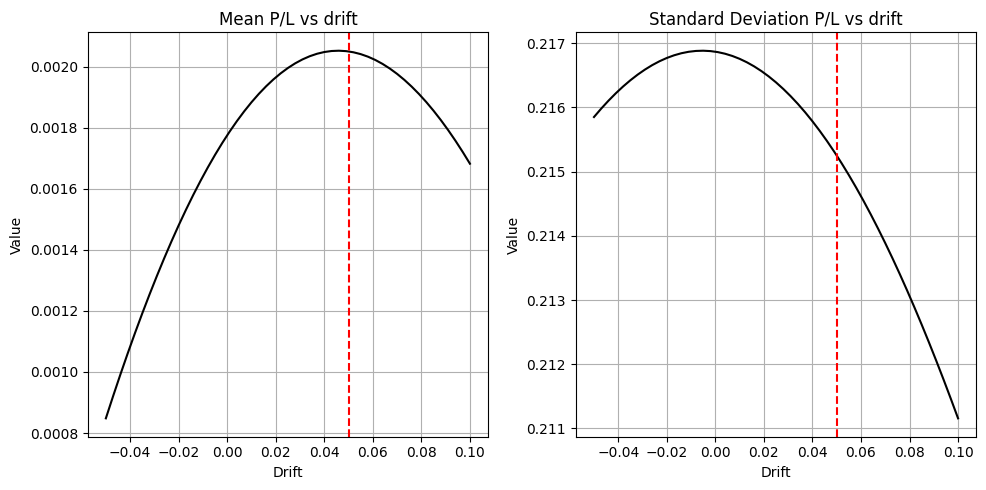

```python
drift = np.linspace(-0.05, 0.1, 51)


def process_step(x):
    S = simulate_gbm_paths(100, 0.05, 0.2, 1, 1000, 1000)
    payoffs = BlackScholesHedgePayoff(S, 100, 0.2, x, 1, 1)
    MC = np.mean(payoffs)
    MCstd = np.std(payoffs)
    return MC, MCstd


results = Parallel(n_jobs=-1)(delayed(process_step)(i) for i in drift)
mean, std = zip(*results)
fig, axs = plt.subplots(1, 2, figsize=(10, 5))
axs[0].plot(
    drift,
    mean,
    linestyle="-",
    color="black",
)
axs[0].axvline(x=0.05, color="red", linestyle="--", label="True Drift")
axs[0].set_title("Mean P/L vs drift")
axs[0].set_xlabel("Drift")
axs[0].set_ylabel("Value")
axs[0].grid(True)
axs[1].plot(
    drift,
    std,
    linestyle="-",
    color="black",
)
axs[1].axvline(x=0.05, color="red", linestyle="--", label="True Drift")
axs[1].set_title("Standard Deviation P/L vs drift")
axs[1].set_xlabel("Drift")
axs[1].set_ylabel("Value")
axs[1].grid(True)
plt.tight_layout()
plt.show()
```

## Effect of insufficient estimated volatility on hedging

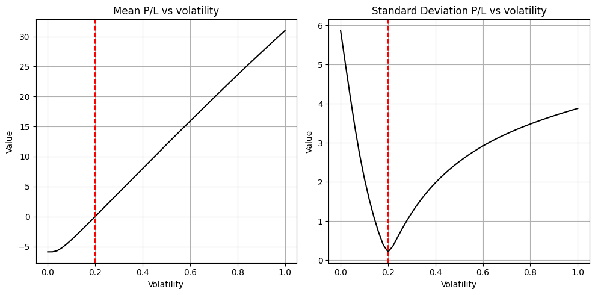

```python
vola = np.linspace(0.0000001, 1, 51)


def process_step(x):
    S = simulate_gbm_paths(100, 0.05, 0.2, 1, 1000, 1000)
    payoffs = BlackScholesHedgePayoff(S, 100, x, 0.05, 1, 1)
    MC = np.mean(payoffs)
    MCstd = np.std(payoffs)
    return MC, MCstd


results = Parallel(n_jobs=-1)(delayed(process_step)(i) for i in vola)
mean, std = zip(*results)
fig, axs = plt.subplots(1, 2, figsize=(10, 5))
axs[0].plot(
    vola,
    mean,
    linestyle="-",
    color="black",
)
axs[0].axvline(x=0.2, color="red", linestyle="--", label="True Volatility")
axs[0].set_title("Mean P/L vs volatility")
axs[0].set_xlabel("Volatility")
axs[0].set_ylabel("Value")
axs[0].grid(True)
axs[1].plot(
    vola,
    std,
    linestyle="-",
    color="black",
)
axs[1].axvline(x=0.2, color="red", linestyle="--", label="True Volatility")
axs[1].set_title("Standard Deviation P/L vs volatility")
axs[1].set_xlabel("Volatility")
axs[1].set_ylabel("Value")
axs[1].grid(True)
plt.tight_layout()
plt.show()
```